# Urban Land-Use Efficiency

A Stable Metric for SDG 11.3.1, and Why Per-Capita Designs Cannot Cleanly Identify Its Drivers: 193 UN Member States x 1985-2020 Panel Analysis

Author

Affiliation

Ömer Furkan Çoban

Carl von Ossietzky University of Oldenburg

Published

June 26, 2026

Abstract

The official SDG 11.3.1 indicator, the ratio of land consumption rate to population growth rate (LCRPGR), is unstable: it divides by a near-zero growth rate and mixes an arithmetic numerator with a logarithmic denominator. We adopt the Built-up per Capita Rate (BpCR), the log change in built-up area per person, a difference of two log growth rates that is finite wherever urban built-up and population are positive. On a harmonised panel of 193 UN member states (1985–2020) built from GHSL grids under the Degree of Urbanisation, we first show that, on identical data, no driver is detectable at the 5% level even under the ratio’s conservative log-form benchmark, while the same design recovers precise associations once BpCR replaces it.

Estimating the drivers of BpCR with two-way fixed-effects and dynamic-panel GMM, we find that built-up area per capita rose in 63% of country-periods (67% of countries on average) and that per-capita land use is clearly path-dependent, though its persistence is only bracketed, not point-identified, once the dynamic model’s failing moment conditions are respected. The driver results are largely cautionary: in per-capita metrics of the BpCR family the compact-city density coefficient is a measurement artefact (urban population enters the metric negatively at $t$ and positively at $t-1$, so density inherits the sign of the date it is measured at); income is indistinguishable from zero; and the one association that survives every check, net in-migration, has a negative *sign* that is close to mechanical (migration drives urban population, which sits in the metric’s denominator) but a *magnitude* that is behaviourally meaningful, the built stock adjusting to migrants at only about a quarter the rate of population. The contribution is thus primarily methodological, a stable metric and a demonstration that per-capita designs can manufacture the very drivers they appear to detect.

Keywords

SDG 11.3.1, Urban land-use efficiency, Built-up per capita rate (BpCR), LCRPGR, Dynamic panel GMM, GHSL / Degree of Urbanisation

# 1 Introduction

The world is urbanising rapidly: by 2050 about two in three people are projected to live in urban areas (United Nations, Department of Economic and Social Affairs, Population Division 2019), and the accompanying land expansion is striking, with global urban land cover forecast to grow by 1.2 million km$^2$ between 2000 and 2030, an area about the size of South Africa (Seto et al. 2012). This is not a developing-world phenomenon alone: the developed world is projected to add a comparable amount of new urban land (Gao and O’Neill 2020). For development policy the central question is not whether cities expand but how efficiently they do so, that is, how much additional land each new urban resident consumes. When built-up area grows in step with population cities stay compact; when it grows much faster they sprawl, paving over farmland, entrenching car dependence, raising per-resident infrastructure costs, and lifting per-capita emissions. Measuring land-use efficiency well is therefore a precondition for monitoring sustainable urbanisation.

The United Nations monitors this through target 11.3 of its Sustainable Development Goals, whose official indicator 11.3.1 is the ratio of the Land Consumption Rate to the Population Growth Rate (LCRPGR) (UN-Habitat 2025). As the agreed global yardstick, its statistical properties determine how every country’s progress is judged, yet it is fragile by construction: with the population-growth rate in the denominator, the ratio diverges and flips sign whenever population is roughly stable, so exactly where land-use efficiency matters most for policy it becomes uninformative.

This paper makes three contributions. First, it documents, on a harmonised global dataset, that LCRPGR is statistically unstable, with its instability concentrated where population growth is near zero, and that the cost is not cosmetic: on identical data and specification, the official ratio leaves every driver undetectable at the 5% level while the log-based Built-up per Capita Rate (BpCR) recovers precise ones. Second, using this stable metric on a dynamic panel of 193 United Nations member states (five-year intervals, 1985–2020; Arellano-Bond and Blundell-Bond GMM against the Nickell bias a static reading ignores), it finds that the behavioural drivers the design appears to identify are fragile once the metric’s arithmetic is taken seriously: income is a null and the one surviving association, net in-migration, has a mechanical negative sign but a behaviourally informative magnitude. Third, it shows that in per-capita regressions of the BpCR family the negative density (compact-city) coefficient is an artefact of the metric’s own arithmetic, a spurious correlation of the kind long known in statistics (Pearson 1897; Kronmal 1993) that arises because density is built from the same population term the metric itself contains and so inherits the sign of the date at which it is measured (Section 6). This is a caution for per-capita designs like ours, not a claim about the footprint-area regressions on which much of the drivers literature rests.

Empirically, one further headline fact stands alongside these three contributions: sprawl is the global norm rather than the exception, with built-up area per capita rising in a clear majority of country-periods. Beyond that, the main lesson is methodological, not substantive: per-capita land-use metrics can manufacture the drivers they seem to detect, and the results above should be read as a caution to that effect rather than as a catalogue of confirmed causes of sprawl.

# 2 Measurement Framework

This section sets out the conceptual core of the paper. We first define the official SDG 11.3.1 indicator and show why it is statistically unstable, and we then introduce the stable, log-based alternative used in the empirical analysis.

## 2.1 The SDG 11.3.1 Indicator and Its Limitations

Following the UN-Habitat metadata (UN-Habitat 2025), the official indicator divides an arithmetic land consumption rate by a logarithmic population growth rate:
$$\text{LCRPGR}_i = \frac{\text{LCR}_i}{\text{PGR}_i},\qquad
\text{LCR}_i=\frac{V_{i,t}-V_{i,t-z}}{V_{i,t-z}}\cdot\frac{1}{z},\qquad
\text{PGR}_i=\frac{\ln(P_{i,t}/P_{i,t-z})}{z},$$
where $V_{i,t}$ and $V_{i,t-z}$ are the urban built-up areas at the end and start of the period, $P_{i,t}$ and $P_{i,t-z}$ the corresponding urban populations, $z$ the period length in years, and $\ln(\cdot)$ the natural logarithm. LCR is thus the *arithmetic* annual growth of built-up area and PGR the *logarithmic* growth of population; this arithmetic-LCR / logarithmic-PGR pairing is the metadata’s own operational specification, not our reading (UN-Habitat 2025; Corbane et al. 2017), and Nicolau et al. (2019) show formally that mixing the two scales is what destabilises the ratio. Two structural problems follow. **(1) Division by a near-zero denominator:** when population is roughly stable ($\text{PGR}\approx 0$) the ratio diverges towards $\pm\infty$ and flips sign, so ordinary demographic differences produce wild, uninterpretable values. **(2) Arithmetic-versus-logarithmic asymmetry:** the arithmetic numerator and logarithmic denominator make the ratio non-symmetric, its tails dominated by an arithmetic artefact rather than real land-use behaviour (Nicolau et al. 2019).

## 2.2 A Stable Metric: The Built-up per Capita Rate (BpCR)

The UN-Habitat metadata itself concedes that the ratio is hard to interpret and offers built-up area per capita ($V/P$) as a secondary indicator (UN-Habitat 2025), a level at one point in time. Building on the log-based direction Lu and Weng (2026) advocate, we turn it into a trend by its annual growth in logarithmic form:
$$\text{BpCR}_{i,t}=\frac{1}{z}\ln\!\left(\frac{V_{i,t}/P_{i,t}}{V_{i,t-z}/P_{i,t-z}}\right)
= \text{LCR}_{i,\log}-\text{PGR}_{i,\log},$$
where $\text{LCR}_{i,\log}=\frac{1}{z}\ln(V_{i,t}/V_{i,t-z})$ and $\text{PGR}_{i,\log}=\frac{1}{z}\ln(P_{i,t}/P_{i,t-z})$ are the logarithmic growth rates of built-up area and population. Here $\text{PGR}_{i,\log}$ is identical to the PGR of the official indicator above, which is already logarithmic, whereas $\text{LCR}_{i,\log}$ is the logarithmic counterpart of the arithmetic $\text{LCR}_i$ in that indicator. Replacing the arithmetic LCR with its logarithmic form is precisely what removes the arithmetic-versus-logarithmic asymmetry that destabilises LCRPGR.

As the **difference of two logarithmic growth rates**, BpCR is finite wherever urban built-up and population are positive, symmetric, additively decomposable, and directly interpretable: $\text{BpCR}>0$ is sprawl (more land per resident), $\text{BpCR}<0$ densification, $\text{BpCR}=0$ land growing in step with population. It is a *descriptive* quantity; the “efficiency” label it and the SDG target carry is normative, and lower BpCR is not unambiguously better, since extreme densification has welfare costs of its own. Where LCRPGR is well-behaved BpCR reproduces its policy signal, but the two are not interchangeable: BpCR stays informative in the near-zero-growth region where the ratio breaks down and, as Section 7 shows, recovers within-country relationships the ratio’s instability hides. In the empirical sections we benchmark it against the *logarithmic* form of the ratio, $\text{LCRPGR}_{\log}=\text{LCR}_{i,\log}/\text{PGR}_{i,\log}$ (*LCRPGR (log)*), a deliberately conservative choice: already free of the arithmetic-versus-logarithmic asymmetry, it differs from BpCR only in being a ratio, so any instability it shows comes purely from the near-zero denominator; the official arithmetic ratio would be more unstable still.

# 3 Literature Review

The literature on urban land use splits into two strands. One asks what *drives* urban expansion; the other scrutinises how land-use efficiency is *measured*. This paper sits at their intersection.

## 3.1 Drivers of Urban Land Expansion

Seto et al. (2011) synthesise 326 remote-sensing studies (1970–2000) and document that urban land has grown faster than urban population almost everywhere, driven mainly by income and, in India and Africa, by population growth. Oueslati et al. (2015) estimate the determinants of sprawl on 282 European cities and find that rising income and population both enlarge the footprint, with cities spreading even where population is flat. Together these establish income and population as the leading drivers, but they work across cities or countries at a single cross-section, leaving open whether the same relationships hold *within* a country over time.

## 3.2 Critiques of the Indicator: Formula and Data

Nicolau et al. (2019) show formally that the SDG 11.3.1 formula is structurally unstable and that a logarithmic, efficiency-based alternative is more robust. Lu and Weng (2026) show that efficiency estimates swing widely with the choice among six built-up and four population datasets and argue for a log-based framework, and Zhong et al. (2025) similarly stress that data and methodological choices shape the resulting picture. This strand establishes that the choice of metric, not only of data, can change the conclusions drawn about sustainable urbanisation.

## 3.3 Research Gap and Contribution

Our contribution sits at the intersection of the two strands. On measurement, we adopt the specific log-based BpCR formulation Lu and Weng (2026) propose, in the spirit of the log-based alternative Nicolau et al. (2019) more generally recommend. On method, we make it dynamic: a two-way fixed-effects panel with Arellano-Bond and Blundell-Bond GMM, estimated on 193 United Nations member states over 1985–2020, that examines the persistence of per-capita land use and probes its purported economic drivers, most of which, as the Results section shows, turn out not to survive scrutiny.

# 4 Data

## 4.1 Data Sources

The empirical analysis draws on three official, global providers, the same sources used in international SDG monitoring. Built-up area, population, and the urban mask come from the **Global Human Settlement Layer (GHSL)** of the European Commission’s Joint Research Centre (Pesaresi et al. 2024; Schiavina et al. 2023): GHS-BUILT-S for built-up surface, GHS-POP for population disaggregated onto it, and GHS-SMOD for the Degree of Urbanisation (DEGURBA) classification that flags urban cells. We use the five-year layers from 1975 to 2020, discarding the modelled 2025 and 2030 projections, with 1975 serving only as the base for the 1980 growth rate (so BpCR is observed over 1980–2020 and, after the lagged dependent variable, the estimation sample spans 1985–2020). Administrative units come from the **Global Administrative Unit Layers (GAUL)** of the UN FAO (FAO 2024), giving UN-validated, politically neutral boundaries. Socio-economic controls come from the **United Nations**: GDP per capita in constant 2020 US dollars from UN SNAAMA and international net migration as a share of population from UN DESA World Population Prospects 2024 (UN SNAAMA 2025; UN DESA WPP 2024). For the heterogeneity analysis we classify countries into UN development groups (developed, developing, and least-developed) using the UN M49 regions and the UN Committee for Development Policy LDC list (UN M49 / UN-CDP 2024). Table 1 summarises each dataset and the coverage used.

Table 1: Dataset specifications. GHSL grids use the World Mollweide projection (ESRI:54009); built-up and population at 100 m, the SMOD urban mask at 1 km. The Years column reports the coverage used in this study, not each source’s native span: the GHSL products span 1975-2030 natively, of which we take 1975-2020 (the 1975 layers serving only as the base for the 1980 growth rate) and discard the modelled 2025 and 2030 projections; the UN series (SNAAMA 1970-2024, WPP 1950-2023) are read only over the epochs the panel needs (Section 4).

| Dataset | Provider | Type | Resolution | CRS | Years | Variable |
| --- | --- | --- | --- | --- | --- | --- |
| GHS-BUILT-S R2023A | EC JRC | Raster | 100 m | Mollweide (54009) | 1975-2020, 5-yr | Built-up area (m2/cell) |
| GHS-POP R2023A | EC JRC | Raster | 100 m | Mollweide (54009) | 1975-2020, 5-yr | Population (persons/cell) |
| GHS-SMOD R2023A | EC JRC | Raster | 1 km | Mollweide (54009) | 1975-2020, 5-yr | Degree of Urbanisation (codes 10-30) |
| GAUL 2024/2025 | FAO | Vector | Levels 0-2 | WGS84 (EPSG:4326) | 2024/2025 | Admin boundaries |
| UN SNAAMA | UN Stats | Tabular | Country-year | -- | 1985-2020, 5-yr | GDP p.c. (const. 2020 US$) |
| UN DESA WPP 2024 | UN DESA | Tabular | Country-year | -- | 1980-2020, annual | Net migration (% of pop.) |
| UN M49 / CDP | UN | Classification | Country | -- | 2024 | Development group |

## 4.2 Constructing the Panel Following the UN Metadata

A central design choice is that we build the panel exactly as the SDG 11.3.1 metadata prescribes (UN-Habitat 2025), so that our BpCR and the official LCRPGR are computed on identical inputs and the comparison is like-for-like. The construction follows the metadata stages.

Figure 1 illustrates the construction for one example window, with each layer drawn over a satellite basemap. Panel (a) is the basemap for reference; panel (b) shows the GHS-BUILT-S surface as the built-up share of each cell; panel (c) the GHS-SMOD Degree of Urbanisation, which classifies each cell from rural to urban centre; and panel (d) the urban-masked built-up that actually enters the analysis, retaining built-up only in cells classified as urban (SMOD at least 21). The same masking is applied to population, so that both components are measured on a consistent urban footprint.

*Analysis area.* SDG 11.3.1 is an urban (city-scale) indicator, measured inside cities rather than over whole national territories. We delineate the urban area with DEGURBA on the GHS-SMOD grid (a cell is urban when its settlement code is at least 21, that is, urban centres and dense or semi-dense towns and suburbs) and measure all built-up and population quantities only over these urban cells. The built-up and population layers are native 100 m grids and the SMOD urban mask is a 1 km grid; we resolve the resolution mismatch by aggregating the 100 m layers to the 1 km SMOD grid before masking, so that all three layers share a common cell.

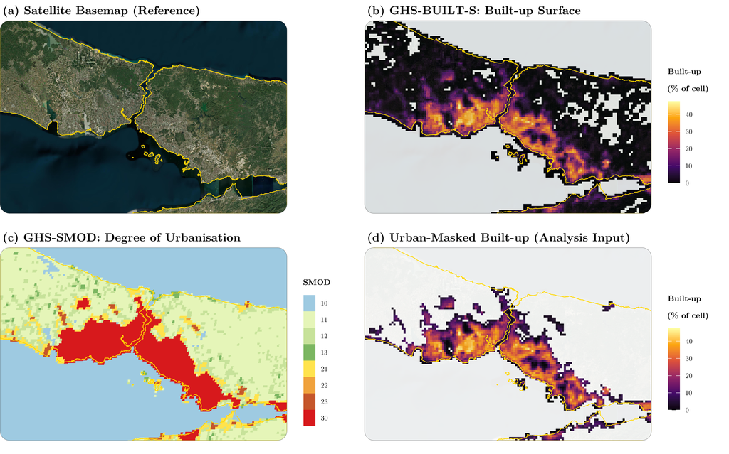

Figure 1: Building the analysis input following the SDG 11.3.1 metadata (Istanbul / Bosphorus window), each layer drawn over an Esri satellite basemap. (a) Basemap. (b) GHS-BUILT-S built-up surface (native 100 m, shown here as the built-up share aggregated to 1 km cells for display, to match the 1 km SMOD grid). (c) GHS-SMOD Degree of Urbanisation (1 km); cells coded 21 or higher count as urban. (d) Urban-masked built-up, the input actually used: panel (b) kept only where panel (c) is urban. The gold line is the GAUL country boundary.

*Components and aggregation.* The unit of analysis is the country, so for each country-period we sum urban built-up area $V$ and urban population $P$ across cells *before* forming any rate (the metadata’s aggregate-then-rate rule): averaging city-level ratios would let a small town with a near-zero denominator dominate the national figure. Boundaries are held fixed at their current GAUL definition for every epoch, so each country is a constant spatial footprint and the within-country changes reflect land-use dynamics rather than shifting borders.

*Rates and controls.* From these national totals we form LCRPGR and BpCR as defined in Section 2. The two urban controls come from the same GHSL/SMOD layers: **urban density** is urban population per urban-cell area, in logs (a settlement density, discussed in Section 6), and **urban population share** is urban population divided by national total population. The remaining controls are international: **GDP per capita** (constant 2020 US dollars, logs) from UN SNAAMA and **net migration** (international, share of population) from UN DESA WPP 2024. All variables align to the same country-period grid.

The resulting panel is unbalanced: it nominally spans 193 United Nations member states, but not fully evenly. Sudan and South Sudan contribute only three of eight epochs, part of the 37 GDP-missing country-periods discussed below (Section 8.2), and Tuvalu only one, DEGURBA flagging no urban centre there until recent decades; that single-period case is the one the within estimator drops for lack of variation. Table 2 traces how the record narrows from the observed BpCR series to each estimator’s sample. Two points carry through the rest of the paper: the fixed-effects columns drop Tuvalu as a single-period within-singleton (1,499 observations, 192 countries), while the GMM columns keep all 193 countries and report genuinely non-zero rows (1,307 and 1,500), net of the structural zero-padding `plm::pgmm` assigns to data-sparse countries (Section 6).

Table 2: Sample flow, from the observed BpCR series to each estimator’s working sample. Arellano-Bond and Blundell-Bond figures are genuinely non-zero rows, net of structural zero-padding for data-sparse countries (Section 6).

| Stage | Country-periods | Countries | Note |
| --- | --- | --- | --- |
| Dependent variable eligible (1985-2020) | 1,538 | 193 | 1980 epoch is lag base only |
| Complete-case working sample | 1,500 | 193 | lag DV and four controls present |
| Fixed-effects estimation | 1,499 | 192 | Tuvalu singleton dropped |
| Arellano-Bond (differenced equation) | 1,307 | 193 | of $193\times7$ nominal |
| Blundell-Bond (level equation) | 1,500 | 193 | of $193\times8$ nominal |
| Clean-timing common sample | 1,336 | -- | t, t-1, t-2 all observed |

# 5 Descriptive Statistics

Table 3: Summary statistics, 1985-2020 (country-periods with an observed BpCR). LCRPGR (log) is the log-form ratio benchmark; BpCR is the log growth of built-up area per capita.

| Variable | N | Mean | SD | Min | Median | Max |
| --- | --- | --- | --- | --- | --- | --- |
| BpCR | 1538 | 0.004 | 0.017 | -0.114 | 0.004 | 0.110 |
| LCRPGR (log) | 1538 | 1.304 | 17.532 | -568 | 1.031 | 281 |
| ln(Urban Density) | 1538 | 7.581 | 0.572 | 5.719 | 7.606 | 9.618 |
| Urban Pop. Share | 1538 | 0.673 | 0.167 | 0.122 | 0.702 | 1.000 |
| ln(GDP per capita) | 1501 | 8.394 | 1.517 | 4.795 | 8.298 | 12.139 |
| Net Migration (% Pop) | 1538 | -0.062 | 1.110 | -13.011 | -0.052 | 13.200 |

Table 3 reports summary statistics, and even before any regression the raw data reveal why the metric matters. Over the 1,538 country-periods, LCRPGR (log) has a standard deviation of about 18 and ranges from roughly -568 to 281, its near-zero denominator producing enormous sign-flipping outliers, whereas BpCR stays in a tight band (standard deviation about 0.0172, roughly 1,020 times narrower) on the same data. Sprawl is the global norm in *direction*: BpCR is positive in 63% of country-periods and 129 of 193 countries (67%) have a positive average, and the official arithmetic ratio exceeds its sprawl threshold of one in 56% of cases. The typical *magnitude* is nonetheless modest: the median country-period BpCR is +0.0041, about 0.4% more land per resident per year, so sprawl is pervasive but slow. The qualitative message is the same under either metric; BpCR simply delivers it without the instability.

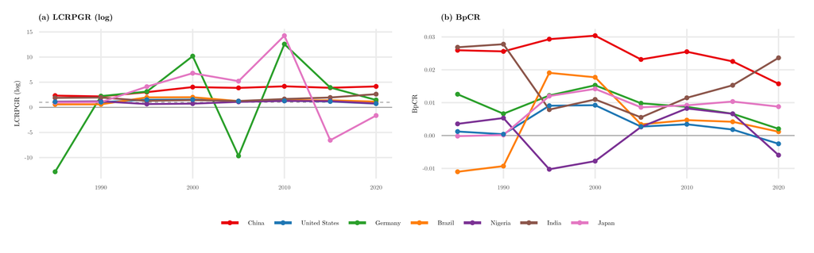

Figure 2: Country trajectories for seven regional representatives, 1985–2020. (a) LCRPGR (log) swings erratically across its zero and unity reference lines; (b) BpCR is smooth on the same data, with the fastest-urbanising economies showing the strongest early sprawl.

Country trajectories make the contrast concrete (Figure 2): LCRPGR (log) swings erratically, crossing zero and spiking to large positive and negative values hard to read as land-use behaviour, whereas the BpCR series for the same countries are smooth and interpretable, most drifting gradually towards balance while the fastest-urbanising economies show the strongest early sprawl.

# 6 Empirical Strategy

**Research question.** We ask two linked questions. The substantive one is what drives *within-country* changes in per-capita urban land use over time, and how persistent they are. The measurement one is whether the official SDG 11.3.1 indicator captures this reliably, or whether the choice of metric changes the conclusions. The measurement question is settled by **H1**, a metric-property comparison rather than a behavioural hypothesis: BpCR captures land-use efficiency more reliably (a better statistical fit) than LCRPGR. The substantive question is formalised in four testable behavioural hypotheses on the drivers of BpCR, each with a sign expected a priori: **H2**, higher urban density lowers land per capita ($-$); **H3**, higher income lowers it ($-$); **H4**, international net in-migration lowers it ($-$); and **H5**, per-capita land use is path-dependent ($+$). We keep these fixed labels throughout.

## 6.1 Specification

We proceed in two stages, each with its own specification, and from here on index time by the panel’s discrete five-year epochs ($t \in \{1985, 1990,\dots,2020\}$), so $t-1$ denotes the previous epoch, five calendar years earlier, the panel’s period length $z$, rather than one calendar year as in the continuous-year notation of Section 2. In the **static** stage we compare the two metrics on an equal footing. For each metric $\text{Metric} \in \{\text{LCRPGR}_{\log}, \text{BpCR}\}$ (we use the conservative log form of the ratio, Section 2) we estimate a two-way fixed-effects model without dynamics:
$$\small \text{Metric}_{i,t} = \beta_1\ln(\text{UrbDens})_{i,t-1} + \beta_2\,\text{UrbShare}_{i,t-1} + \beta_3\ln(\text{GDPpc})_{i,t} + \beta_4\,\text{NetMigr}_{i,t} + \mu_i + \delta_t + \varepsilon_{i,t}.
\tag{1}$$
Because the data, controls, and fixed effects are held identical, any difference between the LCRPGR (log) and BpCR estimates of Equation 1 is attributable to the metric alone (H1).

In the **dynamic** stage, having established BpCR as the usable metric, we add its own lag to measure path-dependence, so the dependent variable is now specifically BpCR:
$$\small \text{BpCR}_{i,t} = \rho\,\text{BpCR}_{i,t-1} + \beta_1\ln(\text{UrbDens})_{i,t-1} + \beta_2\,\text{UrbShare}_{i,t-1} + \beta_3\ln(\text{GDPpc})_{i,t} + \beta_4\,\text{NetMigr}_{i,t} + \mu_i + \delta_t + \varepsilon_{i,t}.
\tag{2}$$
In Equation 2, the coefficient $\rho$ measures how strongly a country’s per-capita land use persists from one period to the next (H5).

The country fixed effects $\mu_i$ absorb all time-invariant national characteristics, so identification comes from changes *within* a country over time, not comparisons *between* countries; the period fixed effects $\delta_t$ absorb global shocks common to all countries in an epoch. Standard errors are clustered by country. Cluster-robust inference is reliable in the pooled models but less so in the development-group splits (Section 7), where the number of clusters is smaller (44 to 101 countries) and only eight periods are observed.

Each regressor has a clear theoretical link to land consumed per resident. **Urban density** captures the compact-city mechanism (H2), though ours is a *settlement* density (population per urban-cell area, about ten times the built-up surface), not the conventional built-up density, chosen to keep the dependent variable’s built-up term $V$ out of the control, a choice weighed in Section 7. **Urban population share** captures the stage of urbanisation. Testing either requires care, because both are built from the urban population count that also sits inside the dependent variable. Writing BpCR out in full,
$$\text{BpCR}_{i,t}=\tfrac{1}{z}\big[\ln V_{i,t}-\ln P^{u}_{i,t}-\ln V_{i,t-1}+\ln P^{u}_{i,t-1}\big],
\tag{3}$$
urban population enters negatively at $t$ and positively at $t-1$, so either control inherits the sign of the date at which it is measured: contemporaneous timing pushes it toward a spurious *negative* (compact-city) sign, lagged timing toward a same-signed spurious *positive*, and only $t-2$ shares no term with the *contemporaneous* $\text{BpCR}_{i,t}$ (it does share one with the lagged dependent variable $\text{BpCR}_{i,t-1}$ in the dynamic model, a collinearity that affects precision, not the identification logic, since $\text{BpCR}_{i,t-1}$ is a regressor, not the estimation target). We adopt $t-1$ for the main specifications (keeping the sample intact and permitting the dynamic GMM) and check every urban-form conclusion against the clean $t-2$ timing (Section 7). **GDP per capita** is ambiguous a priori: cross-country evidence links income to sprawl, while within a country income can fund densification; our design tests which force dominates (H3), a contrast developed in Section 8. It shares only *total* population with BpCR, through its per-capita denominator, a weak one-signed entanglement that biases its coefficient toward positive and leaves any negative estimate conservative. **Net migration**, measured nationally, captures *international* migration and is expected to lower per-capita land if the built stock adjusts more slowly than population to arriving residents (H4). A caveat symmetric to the density one applies: migration *drives* population growth, which enters BpCR negatively through the PGR term (Equation 3), so a mechanical channel runs from more migration to lower BpCR. It is not the literal identity that afflicts density and urban share, since the dependent variable uses *urban* population while the control is *national* migration and built-up area does respond (the decomposition below); but the channel is real, so we read the coefficient as a partly-mechanical conditional association. Internal rural-to-urban migration is not observed (Section 8). Finally, the **lagged dependent variable** captures path-dependence (H5). H1 concerns the metric and is addressed by comparing the LCRPGR and BpCR runs.

## 6.2 Dynamic-Panel Estimation and the Nickell Bias

Adding a lagged dependent variable to a fixed-effects model biases $\rho$ downward: the within transformation that removes $\mu_i$ correlates the transformed lagged regressor with the transformed error, a bias of order $1/T$ that is substantial with only eight periods. We correct it with GMM estimators for dynamic panels. The **Arellano-Bond** (Arellano and Bond 1991) (difference) estimator first-differences away the fixed effects and instruments the differenced lagged term with deeper level lags (lags two to five of BpCR); the **Blundell-Bond** (Blundell and Bond 1998) (system) estimator adds a levels equation instrumented by past differences, gaining efficiency when the series is persistent. Only the lagged dependent variable is instrumented; the four controls are treated as strictly exogenous, a simplification (income in particular is plausibly jointly determined with land use), so the control coefficients are conditional associations rather than clean exogenous effects (Section 8). We take **Arellano-Bond as preferred** and report Blundell-Bond alongside, both in two steps with Windmeijer-corrected standard errors (Windmeijer 2005) and a collapsed instrument matrix (one column per lag distance).

The two estimators’ nominal equation sizes, $N_{AB}=193\times7=1{,}351$ and $N_{\text{level}}=193\times8=1{,}544$, are balanced-grid figures, not complete-case totals: `plm::pgmm` zero-substitutes only unavailable deep-lag *instruments* (Holtz-Eakin et al. 1988; Roodman 2009), never a control, so any country-period missing one is dropped before estimation, not zero-filled. That substitution, though, forces every country into an identical nominal $T-k$ row count regardless of how much real data it contributed, padding concentrated entirely in the 30 data-sparse countries (chiefly the GDP-missing ones, plus the single-period Tuvalu). Table 2 and Table 5 report the genuinely non-zero counts directly instead: 1,307 (Arellano-Bond) and 1,500 (Blundell-Bond level), 97% of each nominal figure. Blundell-Bond’s is one row above the 192-country fixed-effects sample (1,499): its level equation needs no within-country variation to form a valid row, so it alone recovers the single-period Tuvalu case that the fixed-effects singleton correction must drop, while every other country contributes identically to both. Arellano-Bond’s is lower, the extra period first-differencing consumes on top of the lag.

Because the models are estimated in two steps, over-identifying restrictions are assessed with the robust **Hansen** $J$ test, for which a $p$-value above 0.10 does not reject instrument validity. Serial correlation is checked with the Arellano-Bond **AR(1)** and **AR(2)** tests of the differenced residuals: by construction AR(1) should be significant and AR(2) should not, the latter being the condition under which the deeper lags are valid instruments. The collapsed instrument set is also kept well below the number of countries (193) to avoid the instrument-proliferation bias.

# 7 Results

## 7.1 The Metric Matters: LCRPGR vs. BpCR

With the official LCRPGR as the dependent variable, the model detects almost nothing at conventional levels: no control is distinguishable from zero at the 5% level, the largest $t$-statistic is 1.66 (GDP, significant only at 10%), and the point estimates are implausibly large and imprecise, because the metric’s tail outliers swamp any systematic variation. Replacing the dependent variable with BpCR and changing nothing else inverts the picture: the *same* net-migration variable, noise under the ratio ($t = -1.12$), becomes one of the most precisely estimated coefficients in the paper ($t = -5.04$, computed from the unrounded estimate and so not exactly reproducible from Table 4’s four-decimal entries). Table 4 also reports the within $R^2$ (0.003 against 0.212), but we read the contrast as one of **detectability, not explained variance**, the two being variances of different dependent variables: holding data, controls, and fixed effects identical, the ratio buries the economic signal in outlier noise while the log difference recovers it. That is the evidence for H1.

Table 4: Static two-way fixed-effects model on the estimation sample (1985-2020), same sample and controls for both metrics.

| Variables | LCRPGR (log) | BpCR |
| --- | --- | --- |
| ln(Urban Density)[t−1] | -0.7715 | +0.0103* |
|  | (2.2121) | (0.0059) |
| Net Migration (% Pop) | -0.2612 | -0.0064*** |
|  | (0.2341) | (0.0013) |
| ln(GDP per capita) | +2.8668* | -0.0032 |
|  | (1.7293) | (0.0023) |
| Urban Pop. Share[t−1] | -11.8080 | +0.0147 |
|  | (13.0987) | (0.0215) |
| Observations | 1,499 | 1,499 |
| Within R² | 0.0026 | 0.2118 |
| Country FE | Yes | Yes |
| Period FE | Yes | Yes |

*** p<0.01, ** p<0.05, * p<0.1. Standard errors clustered by country, in parentheses.

## 7.2 The Final Dynamic Model

Table 5: Final dynamic-panel model: FE stepwise build-up, Arellano-Bond (difference) and Blundell-Bond (system) GMM.

| Variables | Dependent variable: BpCR Fixed Effects Base | Dependent variable: BpCR Fixed Effects + Density | Dependent variable: BpCR Fixed Effects + Net Migr. | Dependent variable: BpCR Fixed Effects + GDP | Dependent variable: BpCR Fixed Effects + Urban % | Dependent variable: BpCR GMM (Bias-Corrected) Arellano-Bond | Dependent variable: BpCR GMM (Bias-Corrected) Blundell-Bond |
| --- | --- | --- | --- | --- | --- | --- | --- |
| BpCR[t−1] | +0.2535*** | +0.2670*** | +0.2584*** | +0.2565*** | +0.2558*** | +0.2129** | +0.4554*** |
|  | (0.0578) | (0.0555) | (0.0497) | (0.0501) | (0.0505) | (0.1032) | (0.1059) |
| ln(Urban Density)[t−1] |  | +0.0182*** | +0.0165*** | +0.0154*** | +0.0142*** | +0.0371*** | -0.0010 |
|  |  | (0.0050) | (0.0053) | (0.0049) | (0.0051) | (0.0141) | (0.0015) |
| Net Migration (% Pop) |  |  | -0.0065*** | -0.0064*** | -0.0064*** | -0.0062*** | -0.0052*** |
|  |  |  | (0.0011) | (0.0011) | (0.0012) | (0.0022) | (0.0011) |
| ln(GDP per capita) |  |  |  | -0.0026 | -0.0026 | -0.0061 | +0.0007 |
|  |  |  |  | (0.0022) | (0.0022) | (0.0044) | (0.0006) |
| Urban Pop. Share[t−1] |  |  |  |  | +0.0112 | +0.0350 | +0.0087 |
|  |  |  |  |  | (0.0202) | (0.0778) | (0.0063) |
| Observations | 1,499 | 1,499 | 1,499 | 1,499 | 1,499 | 1,307 | 1,500 |
| Within R² | 0.076 | 0.099 | 0.285 | 0.287 | 0.288 | – | – |
| Country FE | Yes | Yes | Yes | Yes | Yes | Yes | Yes |
| Period FE | Yes | Yes | Yes | Yes | Yes | Yes | Yes |
| Instruments | – | – | – | – | – | 15 | 21 |
| Hansen (p) | – | – | – | – | – | 0.05 | 0.01 |
| AR(1) (p) | – | – | – | – | – | 0.01 | 0.02 |
| AR(2) (p) | – | – | – | – | – | 0.76 | 0.62 |

*** p<0.01, ** p<0.05, * p<0.1. Standard errors in parentheses: clustered by country in the fixed-effects columns; two-step GMM with the Windmeijer correction (Windmeijer, 2005) in the GMM columns, where the lagged dependent variable is instrumented by lags 2 to 5 of BpCR with a collapsed instrument matrix.

*Path-dependence (H5).* The lagged term is positive and significant in every estimator, so per-capita land use is unambiguously path-dependent; its precise magnitude, though, we do not pin down, and report as a range rather than a point. The Bond (2002) bracket bounds a consistent $\rho$ between the downward-biased within estimate ($0.26$) and the upward-biased pooled OLS ($0.48$). The estimates within it disagree informatively: the full-model difference GMM ($0.21$, Table 5) even falls below the lower bound, but its Hansen test fails, so we do not read it. Removing the density and urban-share controls, which are arithmetically entangled with BpCR (Equation 3) and contaminate $\rho$ in the differenced equation, restores moment validity and lifts the estimate: Table 6 puts it between $0.34$ and $0.46$ across the specifications whose Hansen tests clear the threshold, close to the value the Nickell (1981) correction implies ($0.45$); the first-stage $F$ of 14.4 does not indicate a weak-instrument problem. (The system estimator lands nearby, at $0.46$, but since its own Hansen test fails we treat that as coincidence, not corroboration.) We conclude that persistence is substantial, plausibly a third to a half of one period’s growth, but decline to report a single coefficient, since the full-model moment failure is exactly why the data do not pin one down.

Table 6: Persistence and its diagnostics as controls enter (difference GMM). Each row adds controls to the same AR(1) dynamic model on the same sample; Arellano-Bond standard errors in parentheses. The Bond (2002) bracket is [FE within, pooled OLS], and the last column is the Arellano-Bond Hansen over-identification p-value. The clean specifications (through income) clear the test and lie inside the bracket; only the arithmetically entangled density and urban-share controls (bottom row) push the estimate below the bracket, and neither this row’s Hansen test nor Blundell-Bond’s clears the conventional threshold. The full row is the model whose control coefficients Table 5 reports.

| Specification | Pooled OLS | FE (within) | Arellano-Bond | AB in bracket | AB Hansen (p) |
| --- | --- | --- | --- | --- | --- |
| AR(1) only | 0.549 | 0.253 (0.058) | 0.458 (0.072) | Yes | 0.42 |
| + Net migration | 0.488 | 0.246 (0.051) | 0.427 (0.090) | Yes | 0.17 |
| + GDP per capita | 0.483 | 0.244 (0.052) | 0.338 (0.132) | Yes | 0.11 |
| + Density, urban share (full) | 0.477 | 0.256 (0.051) | 0.213 (0.103) | No | 0.05 |

*Net migration (H4).* Of the four drivers, net in-migration is the only one whose association is not overturned as an artefact. We read its coefficient primarily from **fixed effects** ($-0.0064$), which need no instrument validity. The full model’s own Arellano-Bond estimate ($-0.0062$, Table 5) comes from the same Hansen-failing specification discussed below and carries no independent weight on its own; a moment-valid Arellano-Bond specification, entered alongside the lagged dependent variable (Hansen $p=0.17$), returns $-0.0063$ instead, closely matching the fixed-effects estimate under instruments the data do not reject. Blundell-Bond, whose Hansen test fails regardless of specification, lands nearby ($-0.0052$, Table 5) but carries no independent weight either. The coefficient is negative, highly significant, and stable across development groups (Table 8) and timings (Table 7). Its interpretation needs care in two directions. The negative *sign* is close to mechanical: net migration is itself a strong driver of urban population, which enters BpCR negatively (Equation 3), so once construction lags population over the five-year window a negative coefficient follows almost by construction. But the result is not *merely* mechanical, and we do not dismiss it as such. The decomposition[^1] shows a one-point rise in net in-migration going with urban population growth higher by about 0.88 percentage points a year *and* built-up growth higher by about 0.24, so per-capita land falls by the difference ($-0.64$). That built-up response is a genuine behavioural elasticity, not part of any identity, and its size relative to population, cities building for migrants at only about a quarter the rate over five years, is the informative, behaviourally meaningful content of the result, a structural fact about how slowly the built stock adjusts. What the negative coefficient alone does *not* license is reading it as evidence that migration triggers deliberate densification, a claim H4 never made and this design cannot test. Migrants also plausibly select into fast-building economies, so treating migration as strictly exogenous is a genuine simplification, but two checks bound its cost. It passes a Wooldridge lead test (future migration does not predict current BpCR, $p=0.70$), and relaxing the assumption barely moves the estimate: treated as *predetermined* and instrumented by its own lags it returns $-0.0064$ against the baseline $-0.0062$, and only the fully *endogenous* treatment, resting on deep lags of a short panel, attenuates it (to $-0.0040$, insignificant). Strict exogeneity is thus a simplification, not a material source of bias here; because selection still cannot be ruled out, we report the coefficient as a conditional association, not a causal effect. It is, moreover, only the *international* channel: the internal rural-to-urban migration that dominates urban growth in developing and least-developed countries is unobserved here (Section 8), so even this association captures the smaller part of the migration story.

*Urban density (H2).* Entered at $t-1$, density is *positive* and significant under fixed effects ($+0.014$). The full model’s Arellano-Bond ($+0.037$) and Blundell-Bond ($-0.001$) estimates come from the same Hansen-failing specification and are not informative either way, not merely because they disagree with each other; unlike migration, density enters our GMM ladder only alongside urban share, at the rung whose Hansen test fails (Table 6), so no moment-valid specification was ever available for it, and we rely on fixed effects and the clean $t-2$ timing alone, never on a GMM magnitude for density. (Its $t-1$ value is $+0.009$, insignificant, on the smaller common-timing sample of Table 7, against $+0.014$ on the full 1,499; both small and positive.) The *negative* compact-city coefficient appears only under contemporaneous timing, a spurious sign from Equation 3; the arithmetically clean $t-2$ coefficient is $+0.011$ ($p<0.05$), which is a weak but genuine result, past *settlement* density goes with slightly *more* land per capita, the opposite of the compact-city direction. The $t-1$ and $t-2$ estimates are themselves statistically indistinguishable from one another, so we do not read $t-1$ as showing the theory’s predicted contamination *in excess of* a clean baseline; Equation 3 predicts only that $t-1$’s bias runs the same, non-negative direction as the clean estimate, not a specific magnitude above it, and the sharply identified part of the evidence is the large sign reversal between $t$ and the lagged timings, not a $t-1$-versus-$t-2$ comparison. That control is settlement density (population per urban-cell area), though, not the *built-up* density the compact-city mechanism turns on, which shares *both* $V$ and the population term of BpCR, is even more entangled with it (Equation 3), and so is not cleanly identifiable in a per-capita design. We therefore neither confirm nor refute the built-up compact-city mechanism; we show that the negative coefficient routinely reported for it is a timing artefact, and that the one clean density estimate available points, weakly, against it. Table 7 also shows net migration immovable across all three timings ($-0.006$ throughout), the mark of a control that shares no growth term with the dependent variable.

Table 7: Clean-timing check (two-way fixed effects, one common sample): the two population-sharing controls entered contemporaneously (t), lagged (t-1), and double-lagged (t-2). The t-2 double lag costs each country a further epoch, so the common sample is 1,336 country-periods, not the main model’s 1,499. Only the t-2 column shares no term with the dependent variable (Equation 3) and is therefore the arithmetically clean reading. Urban density flips from a spurious negative at t to a small positive at the clean t-2, while net migration is immovable across all three timings. Estimate with standard error in parentheses.

|  | Timing of density and urban share Both $t$ | Timing of density and urban share Both $t\text{-}1$ | Timing of density and urban share Both $t\text{-}2$ (clean) |
| --- | --- | --- | --- |
| BpCR[t−1] | +0.1988*** (0.0583) | +0.2472*** (0.0558) | +0.2281*** (0.0595) |
| ln(Urban Density) | -0.0241*** (0.0079) | +0.0092 (0.0067) | +0.0111** (0.0054) |
| Net Migration (% Pop) | -0.0059*** (0.0011) | -0.0061*** (0.0012) | -0.0062*** (0.0011) |
| ln(GDP per capita) | -0.0065** (0.0030) | -0.0043* (0.0026) | -0.0043 (0.0029) |
| Urban Pop. Share | -0.0011 (0.0181) | +0.0191 (0.0261) | -0.0116 (0.0149) |
| Observations | 1,336 | 1,336 | 1,336 |

*Urban population share.* Once lagged, the stage of urbanisation is insignificant, so what matters is the urban *form* a country builds, not how far along the transition it already is.

A word on the over-identification tests is in order, because in the *full* model they are not comfortable: with only 15 and 21 instruments (so this is not instrument proliferation) neither clears the conventional threshold, the Arellano-Bond Hansen $J$ at $p=0.05$ and Blundell-Bond at $p=0.01$. We do not paper over it: a failing Hansen test leaves the over-identifying restrictions unvalidated, so *none* of the full-model GMM estimates, not $\rho$ alone, can be read as consistent, and we hold every coefficient in that column to the same standard, as already applied above to migration and density. The four control coefficients are therefore read from the **fixed-effects columns**, which need no instrument validity; income’s and urban share’s estimates are insignificant there too and we do not interpret their GMM values either way. GMM enters only to bound the Nickell bias on $\rho$, which we report as a range (Table 6), never from the full model but from the moment-valid specifications whose own Hansen tests clear the threshold; even there we decline a point estimate, for the reasons given above. AR(2) holds throughout ($p=0.76$).

## 7.3 Heterogeneity by Development Group

Table 8: Heterogeneity: static two-way fixed-effects BpCR model by United Nations development group (same estimation sample as the static metric comparison above). The density and urban-share coefficients are entered at t-1 and carry the timing artefact of Equation 3; they are shown for completeness but not interpreted (the large LDC urban-share value collapses to insignificance at the clean t-2 timing). Only the net-migration row is read from this table.

| Variables | Dependent variable: BpCR Developed | Dependent variable: BpCR Developing | Dependent variable: BpCR LDC |
| --- | --- | --- | --- |
| ln(Urban Density)[t−1] | +0.0065 | +0.0172*** | -0.0029 |
|  | (0.0083) | (0.0064) | (0.0137) |
| Net Migration (% Pop) | -0.0065*** | -0.0062*** | -0.0066*** |
|  | (0.0007) | (0.0017) | (0.0022) |
| ln(GDP per capita) | -0.0014 | -0.0023 | -0.0076 |
|  | (0.0025) | (0.0024) | (0.0047) |
| Urban Pop. Share[t−1] | -0.0348 | -0.0147 | +0.1122*** |
|  | (0.0335) | (0.0304) | (0.0403) |
| Observations | 369 | 800 | 330 |
| Within R² | 0.3308 | 0.2086 | 0.2927 |
| Countries | 48 | 101 | 44 |
| Country FE | Yes | Yes | Yes |
| Period FE | Yes | Yes | Yes |

*** p<0.01, ** p<0.05, * p<0.1. Standard errors are clustered at the country level, in parentheses, to robustify against potential serial correlation within subgroups.

The pooled model imposes a common slope on a heterogeneous set of countries. Table 8 relaxes this by estimating the static model of Equation 1 separately for the three UN development groups on the same sample as Table 4, using the static fixed-effects estimator because the subgroups (44 to 101 countries) are too small for the deep-lag GMM instruments to be reliable.

Three patterns stand out. First, and most important, the net-migration association is negative, highly significant, and near-identical across all three groups (about $-0.0065$ in each, $p<0.01$), so the headline result is not confined to any development stage. Second, income carries its expected negative sign in every group but is not significant in any of them, consistent with the null in the pooled model. Third, the urban-form coefficients (density and urban share) in this table are entered at $t-1$ and so carry the same timing artefact as the main model (Equation 3, Table 7): we show them for completeness but do not interpret them, and read only migration from the table. The starkest illustration is the large, significant urban-share coefficient among the least-developed countries ($+0.112$); re-estimated at the clean $t-2$ timing on that sub-sample it falls to $+0.045$ and loses significance ($p=0.16$), exactly the collapse the artefact predicts, so it is a measurement artefact, not a genuine least-developed-country effect, and none of the urban-form terms reproduces the compact-city negative sign.

# 8 Discussion

## 8.1 Interpretation and Relation to the Literature

The urban-form finding is a methodological caution (Section 7): any per-capita regression controlling for density at the dependent variable’s own date recovers a negative compact-city coefficient whether or not the mechanism exists, because population enters BpCR with opposite signs at $t$ and $t-1$ (Equation 3); the mechanism proper, resting on the still more entangled built-up density, is not identifiable this way. On measurement, where Nicolau et al. (2019) argue formally that LCRPGR is unstable and Lu and Weng (2026) show its estimates are data-sensitive, our single-dataset comparison (Table 4) adds that the choice of metric, not only of data, can determine the conclusions drawn about sustainable urbanisation.

## 8.2 Limitations and Future Research

Several caveats apply. First, the estimates are associations, not causal effects: the fixed effects absorb a large class of confounders and the GMM corrects the lagged-DV bias, but the controls are treated as strictly exogenous. For migration this simplification is bounded (Section 7): it passes a lead test and is invariant to a predetermined treatment, yet selection into fast-building economies cannot be fully ruled out, so we read it as a conditional association. For density, the within estimate ($+0.014$) and the first-difference estimate ($+0.039$, about $2.8\times$ larger) diverge sharply though both should agree under strict exogeneity, a gap consistent with its violation (though measurement error could also contribute) and a separate concern from the instrument-validity problem discussed in Section 7; together the two are why we read density’s sign only from fixed effects and the clean $t-2$ timing, never from its GMM magnitude. Income we do not interpret in any case, so its exogeneity is moot. Second, the five-year epochs capture medium-run trajectories rather than short-run adjustment. Third, and more seriously, the urban area uses a fixed threshold (SMOD at least 21) on the *multitemporal* mask, so a cell’s urban membership is recomputed each epoch: when a low-density fringe cell first crosses the threshold, its land and residents enter the urban set together, mechanically raising measured per-capita land at the margin. This composition effect can inflate the descriptive “sprawl is the norm” finding; it bears less on the within-country coefficients, identified net of country and period fixed effects, though it is not fully absorbed by them. A fixed final-epoch mask and alternative thresholds are the natural robustness reanalyses and the main measurement extension of this work. Fourth, and most consequentially, our net-migration series is national and captures *international* migration only, whereas the dominant engine of urban growth and sprawl, especially in developing and least-developed countries, is *internal* rural-to-urban migration, which is unobserved here. The surviving migration association thus captures only the smaller international slice; the principal migration driver of urban land use lies outside the design entirely, a further reason we do not present this as identifying the main drivers of sprawl. This scope limitation is also, more precisely, an omitted-variable concern: if internal migration correlates with international net migration within a country over time and independently affects BpCR, the international coefficient is not fully insulated from it. We cannot rule this out without ADM2-level data, but the likely direction is informative: since internal migration plausibly lowers BpCR through the same absorption channel as international migration, a positive within-country correlation between the two would inflate our coefficient’s magnitude rather than reverse its sign, so the qualitative finding is more robust to this omission than its precise size. Fifth, the panel applies present-day boundaries retroactively, so a GDP control is unavailable wherever a country did not yet exist as a separate reporting unit, leaving 37 country-periods, mostly 1985 successor states, that complete-case estimation drops. These point to natural extensions: a sub-national analysis exploiting the ADM2 detail in the data, which would also measure internal migration directly;[^2] designs aimed at causal identification; and an assessment of BpCR as a practical, stable complement to LCRPGR in official SDG 11.3.1 monitoring.

# 9 Conclusion

Urban sprawl is real and measurable, if modest in pace: across 1985–2020, built-up area per capita rose in 63% of country-periods (67% of countries on average), though by a slow median of about 0.4% a year. The difficulty is not the phenomenon but the yardstick. The official LCRPGR is unstable by construction, producing sign-flipping outliers exactly where land-use efficiency matters most; our log-based Built-up per Capita Rate is finite and interpretable for every country-period with an observed urban settlement and recovers, on identical data, an economic signal the official ratio leaves statistically undetectable at the 5% level. That demonstration, rather than the metric itself, is our contribution to the measurement debate.

Using this stable metric on a dynamic panel of 193 United Nations member states, we find per-capita urban land use clearly path-dependent, though its persistence is only bracketed once the dynamic model’s failing moment conditions are respected. The search for behavioural drivers is, tellingly, mostly negative: the negative density coefficient widely cited as compact-city evidence is an artefact of the metric’s own arithmetic (and the mechanism proper, resting on the even more entangled built-up density, is not cleanly testable in a per-capita design); income cannot be distinguished from zero; and the one association that survives, net in-migration, has a mechanical negative sign but a behaviourally meaningful magnitude, a descriptive regularity robust across estimator, timing, and the checks of Section 7, though still a single reduced-form association to be weighted accordingly. The substantive contribution is thus modest and the methodological one central: for monitoring sustainable urbanisation, the choice of metric is not a technicality but a precondition for drawing the right conclusions, and per-capita metrics can manufacture the very drivers they appear to detect.

# Data and Code Availability

All data are drawn from open, official sources (GHSL, GAUL, and the UN series cited in Section 4), and the complete pipeline that builds the panel and produces every result is openly available in the replication repository (https://github.com/ofurkancoban/UrbanLandUseEfficiency_DevEconResearchProj). For space, several further supporting analyses referenced in the text are reported there rather than in the paper, and leave the conclusions unchanged: the four-way Arellano-Bond timing decomposition (the fixed-effects clean-timing check itself is Table 7 here); the strict-exogeneity diagnostics for density (within versus first-difference, plain-OLS and predetermined/endogenous instrumenting) and for migration (the Wooldridge lead test and predetermined/endogenous treatments); the instrument-depth robustness for $\rho$; the net-migration outlier robustness (single-outlier and crisis-country exclusion, and endpoint-year timing) and its small-cluster wild cluster bootstrap; the income-timing check; and the panel unit-root and incremental-Hansen tests underlying the choice between the difference and system GMM estimators.

# References

Arellano, Manuel, and Stephen Bond. 1991. “Some Tests of Specification for Panel Data: Monte Carlo Evidence and an Application to Employment Equations.” *The Review of Economic Studies* 58 (2): 277–97. https://doi.org/10.2307/2297968.

Blundell, Richard, and Stephen Bond. 1998. “Initial Conditions and Moment Restrictions in Dynamic Panel Data Models.” *Journal of Econometrics* 87 (1): 115–43. https://doi.org/10.1016/S0304-4076(98)00009-8.

Bond, Stephen R. 2002. “Dynamic Panel Data Models: A Guide to Micro Data Methods and Practice.” *Portuguese Economic Journal* 1 (2): 141–62. https://doi.org/10.1007/s10258-002-0009-9.

Corbane, Christina, Panagiotis Politis, Alice Siragusa, Thomas Kemper, and Martino Pesaresi. 2017. *LUE User Guide: A Tool to Calculate the Land Use Efficiency and the SDG 11.3 Indicator with the Global Human Settlement Layer*. No. JRC108026. Publications Office of the European Union. https://doi.org/10.2760/212689.

FAO. 2024. *The Global Administrative Unit Layers (GAUL) 2024*. Food and Agriculture Organization of the United Nations. https://data.apps.fao.org/catalog/dataset/global-administrative-unit-layers-gaul-2024.

Gao, Jing, and Brian C. O’Neill. 2020. “Mapping Global Urban Land for the 21st Century with Data-Driven Simulations and Shared Socioeconomic Pathways.” *Nature Communications* 11 (1): 2302. https://doi.org/10.1038/s41467-020-15788-7.

Holtz-Eakin, Douglas, Whitney Newey, and Harvey S. Rosen. 1988. “Estimating Vector Autoregressions with Panel Data.” *Econometrica* 56 (6): 1371–95. https://doi.org/10.2307/1913103.

Kronmal, Richard A. 1993. “Spurious Correlation and the Fallacy of the Ratio Standard Revisited.” *Journal of the Royal Statistical Society: Series A (Statistics in Society)* 156 (3): 379–92. https://doi.org/10.2307/2983064.

Lu, Weipeng, and Qihao Weng. 2026. “From Data Inconsistency to Reliable SDG 11.3.1 Monitoring: A Global Multi-Dataset Assessment of Land Use Efficiency.” *Land Use Policy* 168 (September): 108088. https://doi.org/10.1016/j.landusepol.2026.108088.

Nickell, Stephen. 1981. “Biases in Dynamic Models with Fixed Effects.” *Econometrica* 49 (6): 1417–26. https://doi.org/10.2307/1911408.

Nicolau, Rita, João David, Mário Caetano, and José M. C. Pereira. 2019. “Ratio of Land Consumption Rate to Population Growth Rate: Analysis of Different Formulations Applied to Mainland Portugal.” *ISPRS International Journal of Geo-Information* 8 (1): 10. https://doi.org/10.3390/ijgi8010010.

Oueslati, Walid, Seraphim Alvanides, and Guy Garrod. 2015. “Determinants of Urban Sprawl in European Cities.” *Urban Studies* 52 (9): 1594–614. https://doi.org/10.1177/0042098015577773.

Pearson, Karl. 1897. “Mathematical Contributions to the Theory of Evolution. On a Form of Spurious Correlation Which May Arise When Indices Are Used in the Measurement of Organs.” *Proceedings of the Royal Society of London* 60: 489–98. https://doi.org/10.1098/rspl.1896.0076.

Pesaresi, Martino, Marcello Schiavina, Panagiotis Politis, et al. 2024. “Advances on the Global Human Settlement Layer by Joint Assessment of Earth Observation and Population Survey Data.” *International Journal of Digital Earth* 17 (1). https://doi.org/10.1080/17538947.2024.2390454.

Roodman, David. 2009. “How to Do Xtabond2: An Introduction to Difference and System GMM in Stata.” *The Stata Journal* 9 (1): 86–136. https://doi.org/10.1177/1536867X0900900106.

Schiavina, Marcello, Michele Melchiorri, and Martino Pesaresi. 2023. *GHS-SMOD R2023A - GHS Settlement Layers, Application of the Degree of Urbanisation Methodology (Stage i) to GHS-POP R2023A and GHS-BUILT-S R2023A, Multitemporal (1975-2030)*. European Commission, Joint Research Centre (JRC). https://doi.org/10.2905/A0DF7A6F-49DE-46EA-9BDE-563437A6E2BA.

Seto, Karen C., Michail Fragkias, Burak Güneralp, and Michael K. Reilly. 2011. “A Meta-Analysis of Global Urban Land Expansion.” *PLOS ONE* 6 (8): e23777. https://doi.org/10.1371/journal.pone.0023777.

Seto, Karen C., Burak Güneralp, and Lucy R. Hutyra. 2012. “Global Forecasts of Urban Expansion to 2030 and Direct Impacts on Biodiversity and Carbon Pools.” *Proceedings of the National Academy of Sciences* 109 (40): 16083–88. https://doi.org/10.1073/pnas.1211658109.

UN DESA WPP. 2024. *World Population Prospects 2024*. [Https://population.un.org/wpp/](https://population.un.org/wpp/).

UN M49 / UN-CDP. 2024. *Standard Country or Area Codes for Statistical Use (M49) and UN-CDP Least Developed Countries List*. [Https://unstats.un.org/unsd/methodology/m49/](https://unstats.un.org/unsd/methodology/m49/).

UN SNAAMA. 2025. *National Accounts Main Aggregates Database: GDP Per Capita, Constant 2020 Prices in US Dollars*. [Https://unstats.un.org/unsd/snaama/](https://unstats.un.org/unsd/snaama/).

UN-Habitat. 2025. *SDG Indicator 11.3.1 Metadata: Ratio of Land Consumption Rate to Population Growth Rate*. SDG indicator metadata, harmonized template v1.1. United Nations Human Settlements Programme (UN-Habitat). https://unstats.un.org/sdgs/metadata/files/Metadata-11-03-01.pdf.

United Nations, Department of Economic and Social Affairs, Population Division. 2019. *World Urbanization Prospects: The 2018 Revision*. ST/ESA/SER.A/420. United Nations. https://population.un.org/wup/.

Windmeijer, Frank. 2005. “A Finite Sample Correction for the Variance of Linear Efficient Two-Step GMM Estimators.” *Journal of Econometrics* 126 (1): 25–51. https://doi.org/10.1016/j.jeconom.2004.02.005.

Zhong, Cheng, Luyao Peng, Jie Yu, Isaak Swan, and Hui Li. 2025. “Toward More Reliable, Complete, and Equitable Global Urban Land Use Efficiency Assessments.” *Communications Earth & Environment* 6: 1055. https://doi.org/10.1038/s43247-025-03033-2.

## Footnotes

[^1]: The three figures are the net-migration coefficient from one and the same two-way fixed-effects specification (identical controls, fixed effects, and sample) estimated on each additive component of BpCR in turn, the population growth rate PGR(log), the land growth rate LCR(log), and BpCR itself; since $\text{BpCR}=\text{LCR}_{\log}-\text{PGR}_{\log}$ by construction, the identity carries to the coefficients ($0.24-0.88=-0.64$, in percentage points a year, i.e. 100 times the raw $-0.0064$ of Table 5).
[^2]: A first such case study, for Germany at the *Kreis* level, is provided as supplementary material at https://ofurkancoban.github.io/UrbanLandUseEfficiency_DevEconResearchProj/05_paper/supplementary.pdf.